# Лабораторная работа №6

Администрирование локальных сетей

Ибрахим Мохсейн Алькамаль

1032225432@rudn.ru

Российский университет дружбы народов

2026-03-21

# Информация

## Докладчик

- Ибрахим Мохсейн Алькамаль
- Российский университет дружбы народов
- [GitHub](https://github.com/Ebrahimalkamal2027)

# Цель работы

- Настроить статическую маршрутизацию VLAN в сети

# Выполнение лабораторной работы

## 1. Размещение и подключение маршрутизатора

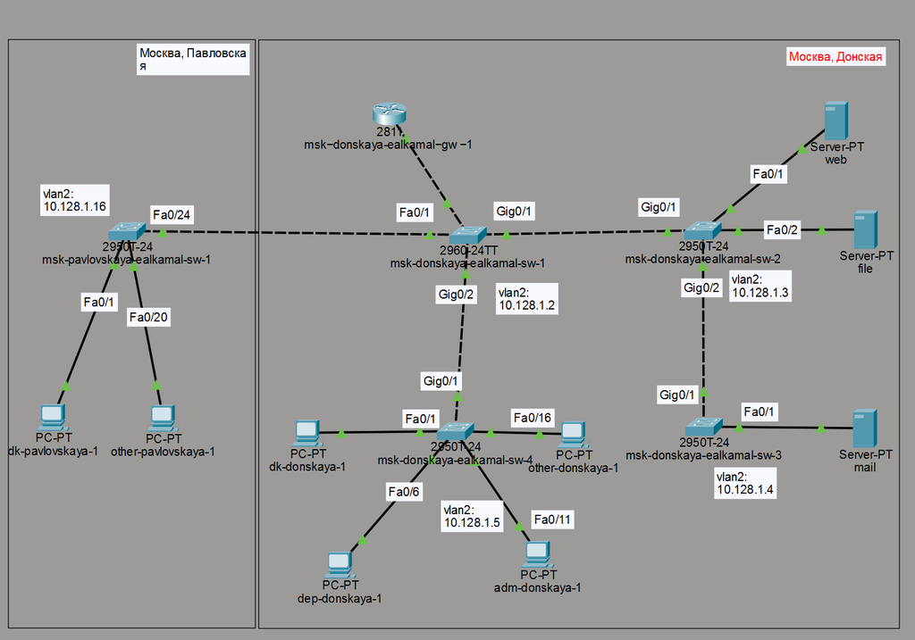

Рисунок 1: Топология сети с подключённым маршрутизатором

## 2. Первичная настройка маршрутизатора

- Задано имя устройства
- Настроены пароли (console и vty)
- Включено шифрование паролей
- Создан пользователь
- Сгенерированы RSA-ключи
- Настроен доступ по SSH

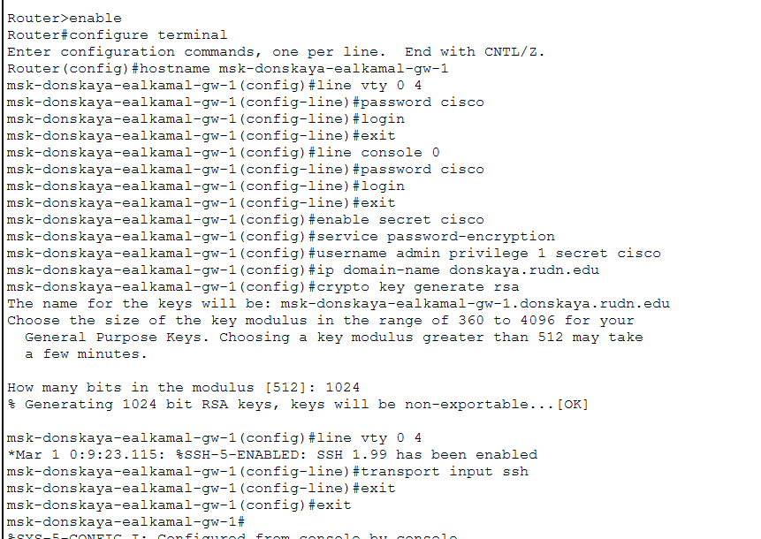

Рисунок 2: Первичная настройка маршрутизатора и настройка SSH

## 3. Настройка trunk-порта на коммутаторе

- Интерфейс FastEthernet0/24 переведён в режим trunk
- Обеспечена передача нескольких VLAN

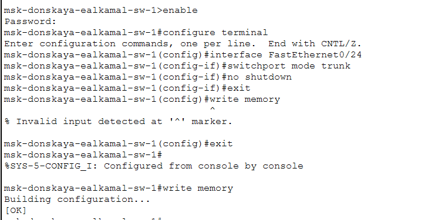

Рисунок 3: Настройка trunk-порта на коммутаторе

## 4. Активация интерфейса маршрутизатора

- Интерфейс FastEthernet0/0 активирован
- Выполнена команда no shutdown
- Интерфейс перешёл в состояние up

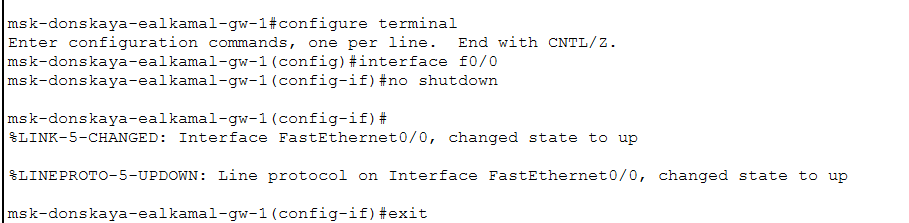

Рисунок 4: Активация интерфейса FastEthernet0/0

## 5. Настройка подинтерфейса VLAN 2

- Создан интерфейс FastEthernet0/0.2
- Настроена encapsulation dot1Q 2
- Назначен IP 10.128.1.1/24
- Используется как шлюз VLAN 2

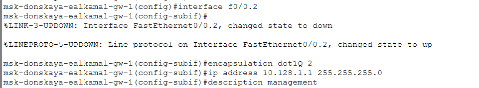

Рисунок 5: Настройка подинтерфейса VLAN 2

## 6. Настройка подинтерфейса VLAN 3

- Создан интерфейс FastEthernet0/0.3
- Настроена encapsulation dot1Q 3
- Назначен IP 10.128.0.1/24

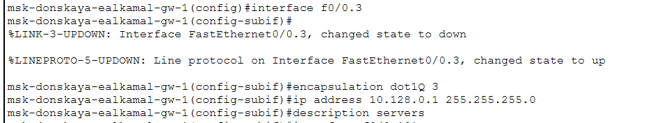

Рисунок 6: Настройка подинтерфейса VLAN 3

## 7. Настройка подинтерфейсов VLAN 101–104

- Созданы интерфейсы FastEthernet0/0.101–104
- Настроена encapsulation dot1Q для каждой VLAN
- Назначены IP-адреса
- Обеспечена маршрутизация между VLAN

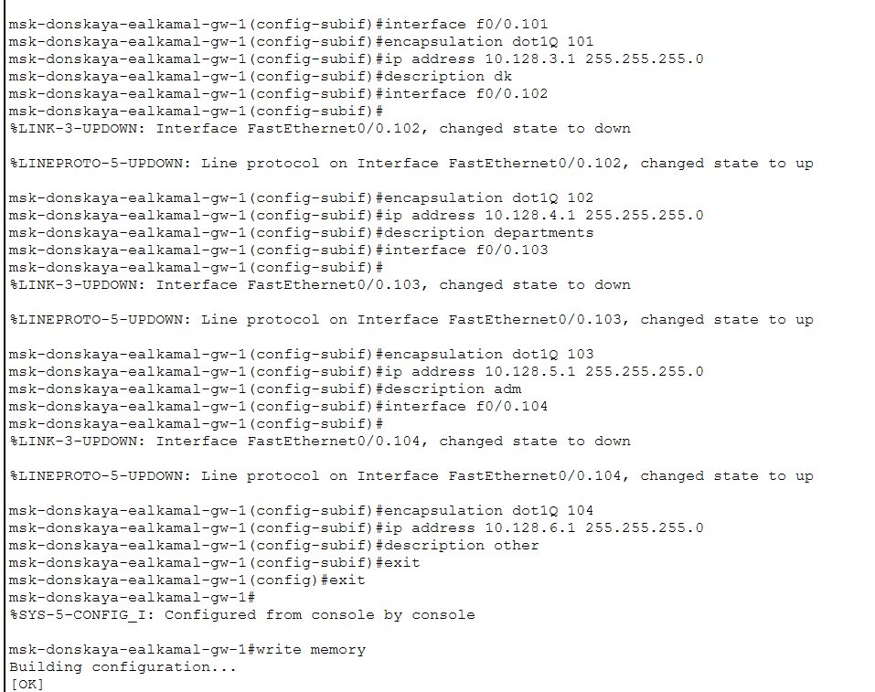

Рисунок 7: Настройка подинтерфейсов VLAN 101–104

## 8. Проверка состояния интерфейсов

- Выполнена команда show ip interface brief
- Все подинтерфейсы в состоянии up
- Конфигурация корректна

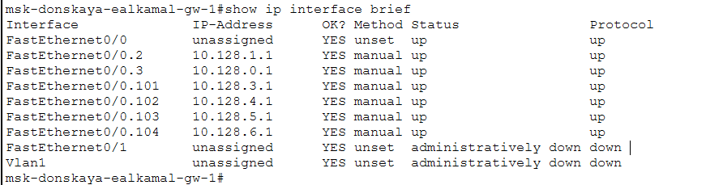

Рисунок 8: Вывод команды show ip interface brief

## 9. Проверка доступности устройств (VLAN 101 → VLAN 102)

- Выполнен ping с dk-donskaya-1
- Проверка адреса 10.128.4.2
- Получены ответы

[figure not shown]

Рисунок 9: Проверка связи между VLAN 101 и VLAN 102

## 10. Проверка доступности устройств (VLAN 102 → VLAN 103)

- Выполнен ping с dep-donskaya-1
- Проверка адреса 10.128.5.2
- Получены ответы

[figure not shown]

Рисунок 10: Проверка связи между VLAN 102 и VLAN 103

## 11. Проверка доступности устройств (VLAN 103 → VLAN 104)

- Выполнен ping с adm-donskaya-1
- Проверка адреса 10.128.6.2
- Получены ответы

[figure not shown]

Рисунок 11: Проверка связи между VLAN 103 и VLAN 104

## 12. Проверка доступности устройств (VLAN 104 → VLAN 101)

- Выполнен ping с other-donskaya-1
- Проверка адреса 10.128.3.2
- Потерь пакетов нет

[figure not shown]

Рисунок 12: Проверка связи между VLAN 104 и VLAN 101

## 13. Анализ передачи пакета в режиме Simulation

- Использован режим Simulation
- Отслежен путь ICMP-пакета
- Пакет проходит через коммутаторы
- Обрабатывается маршрутизатором
- Используются trunk-соединения

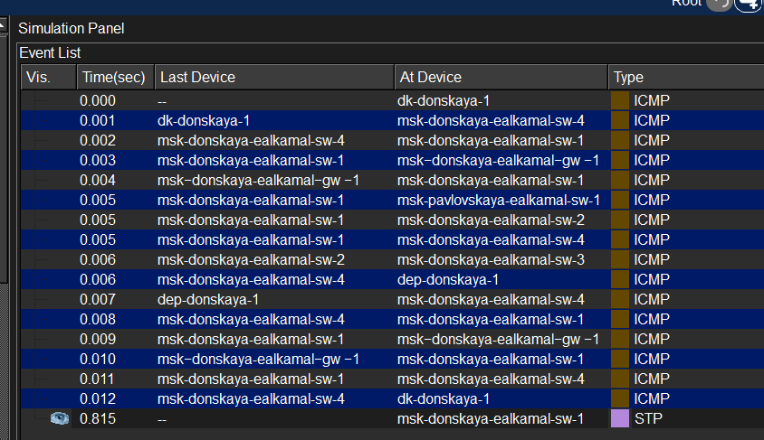

Рисунок 13: Анализ ICMP-пакета в режиме Simulation

# Выводы

- Добавлен и настроен маршрутизатор Cisco 2811
- Настроен trunk между коммутатором и маршрутизатором
- Реализованы подинтерфейсы VLAN (802.1Q)
- Интерфейсы находятся в состоянии up
- Связь между VLAN подтверждена ping
- Передача пакетов соответствует модели OSI
- Используются принципы маршрутизации IP-сетей